# Spr2017-Proj1-SongWangColumbia

# Step 0: check and install needed packages. Load the libraries and functions.

# Step 1: Data harvest: scrap speech URLs from http://www.presidency.ucsb.edu/.

For this project, we selected all inaugural addresses of past presidents

# Step 2: Using speech metadata posted on http://www.presidency.ucsb.edu/, I use CSV data sets provided by Prof Tian for the speeches we will scrap.

To assemble all scrapped links to full text transcripts into one list.

# Step 3: scrap the texts of speeches from the speech URLs.

Based on the list of speeches, I scrap the main text part of the transcript’s html page. For reproducibility, I also save our scrapped speeches into our local folder as individual speech files.

# Step 4: data Processing — generate list of sentences

“we apply sentiment analysis using [NRC sentiment lexion](http://saifmohammad.com/WebPages/NRC-Emotion-Lexicon.htm).”The NRC Emotion Lexicon is a list of English words and their associations with eight basic emotions (anger, fear, anticipation, trust, surprise, sadness, joy, and disgust) and two sentiments (negative and positive). The annotations were manually done by crowdsourcing.“”

Some non-sentences exist in raw data due to erroneous extra end-of sentence marks.

# Step 5: Data analysis — length of sentences

## sentence length distribution of each party

It is quite clearly that,for both parties,they tend to use shorter sentences compared with the early times,and the sentence length distribution of a certain speech behave more and more like a Spindly as time goes by.for the Republicans the mass concentrated on the middle length is more obviously than the democratics.

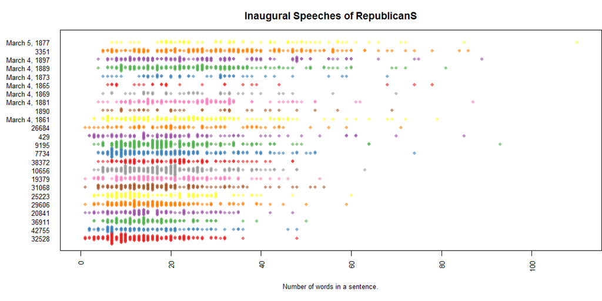

```r
sentence.list.Republican=sentence.list%>%filter(type=="inaug",Party=="Republican")
sentence.list.Republican$File=factor(sentence.list.Republican$Date)
sentence.list.Republican$FileOrdered=reorder(sentence.list.Republican$Date,
                                  sentence.list.Republican$word.count,
                                  mean,
                                 order=T)
#margin
par(mar=c(5, 6, 3, 0))
beeswarm(word.count~FileOrdered,
         data=sentence.list.Republican,
         horizontal = TRUE,
         pch=16, col=alpha(brewer.pal(9, "Set1"), 0.6),
         cex=0.9, cex.axis=0.8, cex.lab=0.8,
         spacing=5/nlevels(sentence.list.Republican$FileOrdered),
         las=2, ylab="", xlab="Number of words in a sentence.",
         main="Inaugural Speeches of RepublicanS")
```

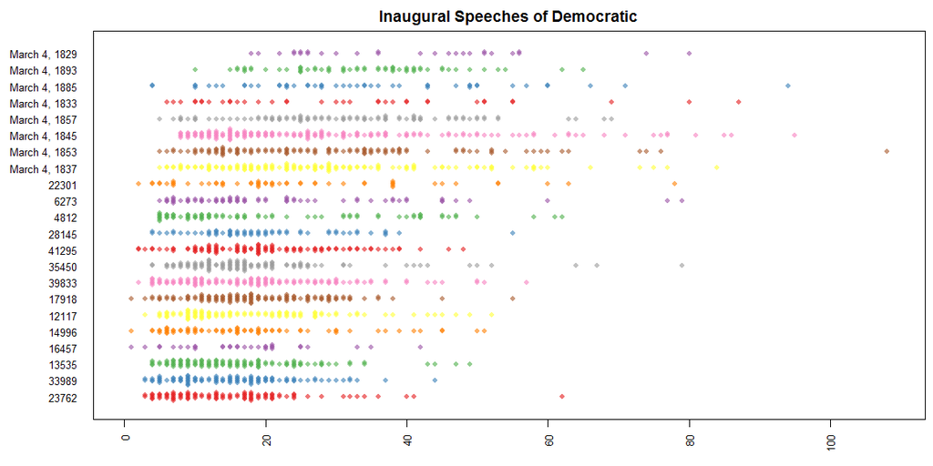

```r
sentence.list.Democratic=sentence.list%>%filter(type=="inaug",Party=="Democratic")
sentence.list.Democratic$File=factor(sentence.list.Democratic$Date)
sentence.list.Democratic$FileOrdered=reorder(sentence.list.Democratic$Date,
                                  sentence.list.Democratic$word.count,
                                  mean,
                                  order=T)
par(mar=c(3, 6, 2, 0.5))
beeswarm(word.count~FileOrdered,
         data=sentence.list.Democratic,
         horizontal = TRUE,
         pch=16, col=alpha(brewer.pal(9, "Set1"), 0.6),
         cex=0.9, cex.axis=0.8, cex.lab=0.8,
         spacing=5/nlevels(sentence.list.Democratic$FileOrdered),
         las=2, ylab="", xlab="Number of words in a sentence.",
         main="Inaugural Speeches of Democratic")
```

# Step 5: Data analysis — sentiment analsis

## Sentence length variation over the course of the speech, with emotions.

How our presidents (or candidates) alternate between long and short sentences and how they shift between different sentiments in their speeches. It is interesting to note that some presidential candidates’ speech are more colorful than others.

# try to write a shinyapp based on the code provided by Prof Tian in Week 1-2,so that the result of sentiment analysis of any inaugural speech can be can be choosed and dislaced.

```r
  # library(shiny)
  #
  # shinyApp(
  #     ui = fluidPage(fluidRow(style = "padding-bottom: 20px;",
  #         column(4, selectInput('speech1', 'Speech 1',speech.list,
  #                              selected=speech.list[5]))),
  #       fluidRow(plotOutput(speech.list, height = "400px"))
  #
  #     server = function(input, output, session) {
  #
  #       # Combine the selected variables into a new data frame
  #       selectedData <- reactive({
  #        list(dtm.term1=ff.dtm$term[ff.dtm$document==as.character(input$speech1)],
  #              dtm.count1=ff.dtm$count[ff.dtm$document==as.character(input$speech1)]})##,
 #              dtm.term2=ff.dtm$term[ff.dtm$document==as.character(input$speech2)],
 #              dtm.count2=ff.dtm$count[ff.dtm$document==as.character(input$speech2)])
 #       })
 #
 #       output$emotion <- f.plotsent.len(In.list=sentence.list, InFile="speech.list",
#               InType="inaug", InTerm=1, President="George W. Bush")
          #renderPlot(height = 400, {
 #         par(mfrow=c(1,2), mar = c(0, 0, 3, 0))
 #         wordcloud(selectedData()$dtm.term1,
 #                   selectedData()$dtm.count1,
 #               scale=c(4,0.5),
 #               max.words=input$nwords,
 #               min.freq=1,
 #               random.order=FALSE,
 #               rot.per=0,
 #               use.r.layout=FALSE,
 #               random.color=FALSE,
 #               colors=brewer.pal(10,"Blues"),
 #             main=input$speech1)
 #         wordcloud(selectedData()$dtm.term2,
 #                   selectedData()$dtm.count2,
 #               scale=c(4,0.5),
 #               max.words=input$nwords,
 #               min.freq=1,
 #               random.order=FALSE,
 #               rot.per=0,
 #               use.r.layout=FALSE,
 #               random.color=FALSE,
 #               colors=brewer.pal(10,"Blues"),
 #             main=input$speech2)
 #      })
 #     },
 #
 #     options = list(height = 600)
  #)
 #

par(mfrow=c(4,1), mar=c(1,0,2,0), bty="n", xaxt="n", yaxt="n", font.main=1)
f.plotsent.len(In.list=sentence.list, InFile="WilliamJClinton",
               InType="inaug", InTerm=1, President="William J. Clinton")
f.plotsent.len(In.list=sentence.list, InFile="GeorgeWBush",
               InType="inaug", InTerm=1, President="George W. Bush")
```

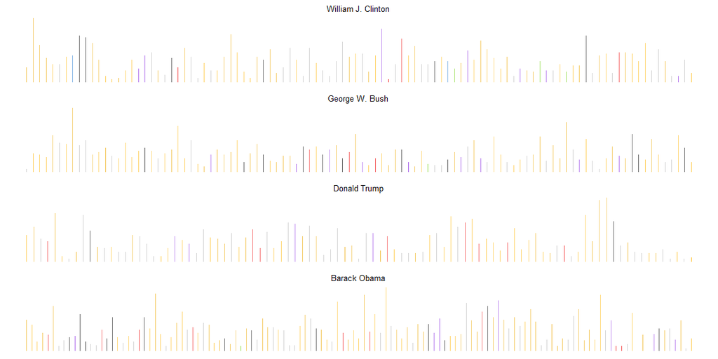

```r
f.plotsent.len(In.list=sentence.list, InFile="DonaldJTrump",
               InType="inaug", InTerm=1, President="Donald Trump")
f.plotsent.len(In.list=sentence.list, InFile="BarackObama",
               InType="inaug", InTerm=1, President="Barack Obama")
```

### What are the emotionally charged sentences?

```r
print("WilliamJClinton")
```

```
[1] "WilliamJClinton"
```

```r
speech.df=tbl_df(sentence.list)%>%
  filter(File=="William J. Clinton", type=="inaug", Term==1, word.count>=4)%>%
  select(sentences, anger:trust)
speech.df=as.data.frame(speech.df)
as.character(speech.df$sentences[apply(speech.df[,-1], 2, which.max)])
```

```
character(0)
```

```r
print("George W. Bush")
```

```
[1] "George W. Bush"
```

```r
speech.df=tbl_df(sentence.list)%>%
  filter(File=="GeorgeWBush", type=="inaug", word.count>=4)%>%
  select(sentences, anger:trust)
speech.df=as.data.frame(speech.df)
as.character(speech.df$sentences[apply(speech.df[,-1], 2, which.max)])
```

```
[1] "Abandonment and abuse are not acts of God;"
[2] "God bless you all, and God bless America."
[3] "Where there is suffering, there is duty."
[4] "Abandonment and abuse are not acts of God;"
[5] "God bless you all, and God bless America."
[6] "Abandonment and abuse are not acts of God;"
[7] "Liberty for all does not mean independence from one another."
[8] "God bless you all, and God bless America."
```

```r
print("Barack Obama")
```

```
[1] "Barack Obama"
```

```r
speech.df=tbl_df(sentence.list)%>%
  filter(File=="BarackObama", type=="inaug", Term==1, word.count>=5)%>%
  select(sentences, anger:trust)
speech.df=as.data.frame(speech.df)
as.character(speech.df$sentences[apply(speech.df[,-1], 2, which.max)])
```

```
[1] "On this day, we gather because we have chosen hope over fear, unity of purpose over conflict and discord."
[2] "This is the journey we continue today."
[3] "We remain the most prosperous, powerful nation on Earth."
[4] "Our Nation is at war against a far-reaching network of violence and hatred."
[5] "We remain the most prosperous, powerful nation on Earth."
[6] "Our Nation is at war against a far-reaching network of violence and hatred."
[7] "This is the meaning of our liberty and our creed;"
[8] "God bless you, and God bless the United States of America."
```

```r
print("Donald Trump")
```

```
[1] "Donald Trump"
```

```r
speech.df=tbl_df(sentence.list)%>%
  filter(File=="DonaldJTrump", type=="inaug", Term==1, word.count>=5)%>%
  select(sentences, anger:trust)
speech.df=as.data.frame(speech.df)
as.character(speech.df$sentences[apply(speech.df[,-1], 2, which.max)])
```

```
[1] "No challenge can match the heart and fight and spirit of America."
[2] "God bless you, and God bless America."
[3] "America will start winning again, winning like never before."
[4] "No challenge can match the heart and fight and spirit of America."
[5] "Today's ceremony, however, has very special meaning."
[6] "America will start winning again, winning like never before."
[7] "Today's ceremony, however, has very special meaning."
[8] "God bless you, and God bless America."
```

## Clustering of emotions

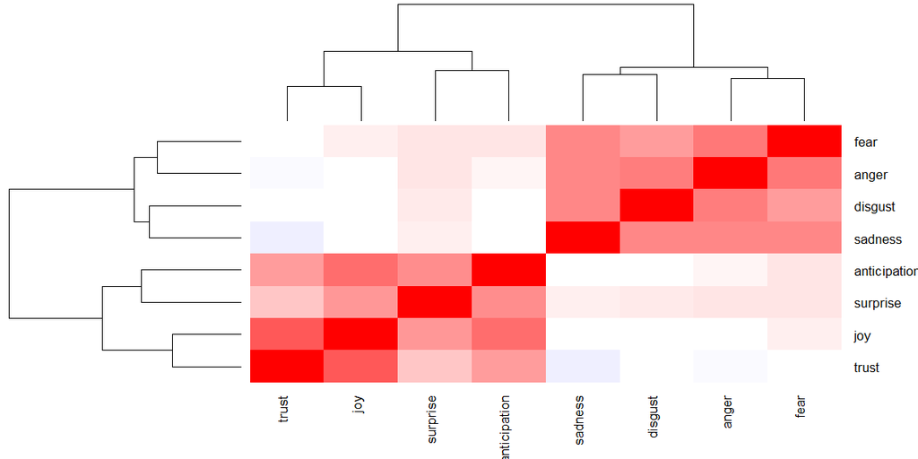

```r
heatmap.2(cor(sentence.list%>%filter(type=="inaug")%>%select(anger:trust)),
          scale = "none",
          col = bluered(100), , margin=c(6, 6), key=F,
          trace = "none", density.info = "none")
par(mar=c(3, 4, 2, 1))
```

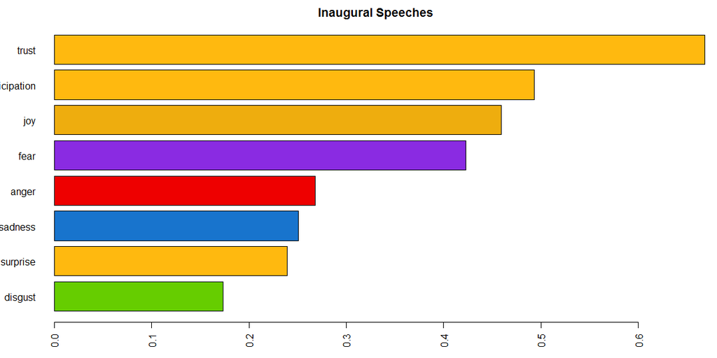

```r
emo.means=colMeans(select(sentence.list, anger:trust)>0.01)
col.use=c("red2", "darkgoldenrod1",
            "chartreuse3", "blueviolet",
            "darkgoldenrod2", "dodgerblue3",
            "darkgoldenrod1", "darkgoldenrod1")
barplot(emo.means[order(emo.means)], las=2, col=col.use[order(emo.means)], horiz=T, main="Inaugural Speeches")
```

```r
presid.summary=tbl_df(sentence.list)%>%
  filter(type=="inaug")%>%
  #group_by(paste0(type, File))%>%
  group_by(File)%>%
  summarise(
    anger=mean(anger),
    anticipation=mean(anticipation),
    disgust=mean(disgust),
    fear=mean(fear),
    joy=mean(joy),
    sadness=mean(sadness),
    surprise=mean(surprise),
    trust=mean(trust)
    #negative=mean(negative),
    #positive=mean(positive)
  )

presid.summary=as.data.frame(presid.summary)
rownames(presid.summary)=as.character((presid.summary[,1]))
km.res=kmeans(presid.summary[,-1], iter.max=200,
              5)
fviz_cluster(km.res,
             stand=F, repel= TRUE,
             data = presid.summary[,-1], xlab="", xaxt="n",
             show.clust.cent=FALSE)
```

[output not shown]

# Step 5: Data analysis — Topic modeling

For topic modeling, we prepare a corpus of sentence snipets as follows. For each speech, we start with sentences and prepare a snipet with a given sentence with the flanking sentences.

```r
sentence.list.inaug=sentence.list%>%filter(type=="inaug", Term==1)
sentence.list.inaug$File=factor(sentence.list.inaug$File)

sentence.list.inaug$FileOrdered=reorder(sentence.list.inaug$File,
                                  sentence.list.inaug$word.count,
                                  mean,
                                  order=T)
corpus.list=sentence.list.inaug[2:(nrow(sentence.list.inaug)-1), ]
sentence.pre=sentence.list.inaug$sentences[1:(nrow(sentence.list.inaug)-2)]
sentence.post=sentence.list.inaug$sentences[3:(nrow(sentence.list.inaug)-1)]
corpus.list$snipets=paste(sentence.pre, corpus.list$sentences, sentence.post, sep=" ")
rm.rows=(1:nrow(corpus.list))[corpus.list$sent.id==1]
rm.rows=c(rm.rows, rm.rows-1)
corpus.list=corpus.list[-rm.rows, ]
```

## Text mining

```r
docs <- Corpus(VectorSource(corpus.list$snipets))
writeLines(as.character(docs[[sample(1:nrow(corpus.list), 1)]]))
```

[output not shown]

### Text basic processing

Adapted from https://eight2late.wordpress.com/2015/09/29/a-gentle-introduction-to-topic-modeling-using-r/.

```r
#remove potentially problematic symbols
docs <-tm_map(docs,content_transformer(tolower))
writeLines(as.character(docs[[sample(1:nrow(corpus.list), 1)]]))

#remove punctuation
docs <- tm_map(docs, removePunctuation)
writeLines(as.character(docs[[sample(1:nrow(corpus.list), 1)]]))

#Strip digits
docs <- tm_map(docs, removeNumbers)
writeLines(as.character(docs[[sample(1:nrow(corpus.list), 1)]]))

#remove stopwords
docs <- tm_map(docs, removeWords, stopwords("english"))
writeLines(as.character(docs[[sample(1:nrow(corpus.list), 1)]]))

#remove whitespace
docs <- tm_map(docs, stripWhitespace)
writeLines(as.character(docs[[sample(1:nrow(corpus.list), 1)]]))

#Stem document
docs <- tm_map(docs,stemDocument)
writeLines(as.character(docs[[sample(1:nrow(corpus.list), 1)]]))
```

[output not shown]

### Topic modeling

Gengerate document-term matrices.

```r
dtm <- DocumentTermMatrix(docs)
#convert rownames to filenames#convert rownames to filenames
rownames(dtm) <- paste(corpus.list$type, corpus.list$File,
                       corpus.list$Term, corpus.list$sent.id, sep="_")

rowTotals <- apply(dtm , 1, sum) #Find the sum of words in each Document

dtm  <- dtm[rowTotals> 0, ]
corpus.list=corpus.list[rowTotals>0, ]
```

Run LDA

```r
#Set parameters for Gibbs sampling
burnin <- 4000
iter <- 2000
thin <- 500
seed <-list(2003,5,63,100001,765)
nstart <- 5
best <- TRUE

#Number of topics
k <- 15

#Run LDA using Gibbs sampling
ldaOut <-LDA(dtm, k, method="Gibbs", control=list(nstart=nstart,
                                                 seed = seed, best=best,
                                                 burnin = burnin, iter = iter,
                                                 thin=thin))
#write out results
#docs to topics
ldaOut.topics <- as.matrix(topics(ldaOut))
table(c(1:k, ldaOut.topics))
write.csv(ldaOut.topics,file=paste("../output/LDAGibbs",k,"DocsToTopics.csv"))

#top 6 terms in each topic
ldaOut.terms <- as.matrix(terms(ldaOut,20))
write.csv(ldaOut.terms,file=paste("../output/LDAGibbs",k,"TopicsToTerms.csv"))

#probabilities associated with each topic assignment
topicProbabilities <- as.data.frame(ldaOut@gamma)
write.csv(topicProbabilities,file=paste("../output/LDAGibbs",k,"TopicProbabilities.csv"))
```

[output not shown]

```r
terms.beta=ldaOut@beta
terms.beta=scale(terms.beta)
topics.terms=NULL
for(i in 1:k){
  topics.terms=rbind(topics.terms, ldaOut@terms[order(terms.beta[i,], decreasing = TRUE)[1:7]])
}
topics.terms
ldaOut.terms
```

[output not shown]

Based on the most popular terms and the most salient terms for each topic, we assign a hashtag to each topic. (This part require manual setup as the topics are likely to change. )

```r
topics.hash=c("Economy", "America", "Defense", "Belief", "Election", "Patriotism", "Unity", "Government", "Reform", "Temporal", "WorkingFamilies", "Freedom", "Equality", "Misc", "Legislation")
corpus.list$ldatopic=as.vector(ldaOut.topics)
corpus.list$ldahash=topics.hash[ldaOut.topics]

colnames(topicProbabilities)=topics.hash
corpus.list.df=cbind(corpus.list, topicProbabilities)
```

## Clustering of topics

```r
par(mar=c(1,1,1,1))
topic.summary=tbl_df(corpus.list.df)%>%
              filter(type%in%c("inaug"))%>%
              select(File, Economy:Legislation)%>%
              group_by(File)%>%
              summarise_each(funs(mean))
topic.summary=as.data.frame(topic.summary)
rownames(topic.summary)=topic.summary[,1]
# [1] "Economy"         "America"         "Defense"         "Belief"
# [5] "Election"        "Patriotism"      "Unity"           "Government"
# [9] "Reform"          "Temporal"        "WorkingFamilies" "Freedom"
# [13] "Equality"        "Misc"            "Legislation"
topic.plot=c(1, 13, 9, 11, 8, 3, 7)
print(topics.hash[topic.plot])
```

```
[1] "Economy"         "Equality"        "Reform"          "WorkingFamilies"
[5] "Government"      "Defense"         "Unity"
```

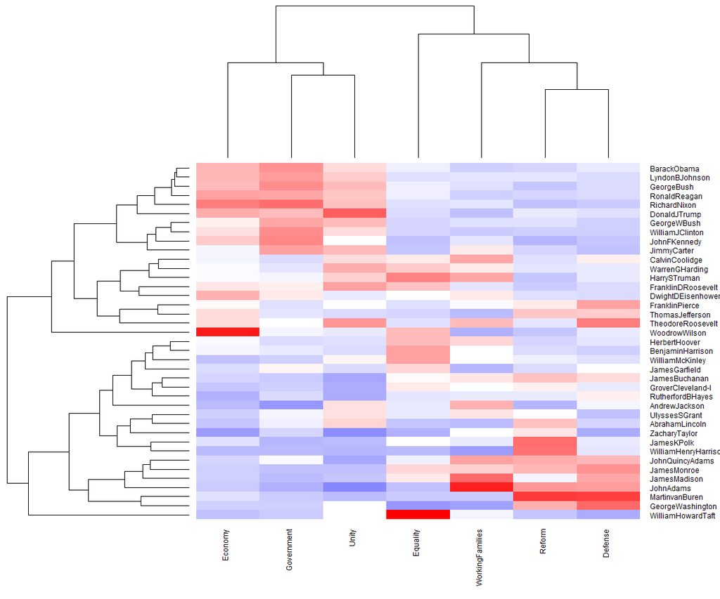

```r
heatmap.2(as.matrix(topic.summary[,topic.plot+1]),
          scale = "column", key=F,
          col = bluered(100),
          cexRow = 0.9, cexCol = 0.9, margins = c(8, 8),
          trace = "none", density.info = "none")
```

```r
# [1] "Economy"         "America"         "Defense"         "Belief"
# [5] "Election"        "Patriotism"      "Unity"           "Government"
# [9] "Reform"          "Temporal"        "WorkingFamilies" "Freedom"
# [13] "Equality"        "Misc"            "Legislation"


par(mfrow=c(5, 1), mar=c(1,1,2,0), bty="n", xaxt="n", yaxt="n")


topic.plot=c(1, 13, 14, 15, 8, 9, 12)
print(topics.hash[topic.plot])

speech.df=tbl_df(corpus.list.df)%>%filter(File=="GeorgeBush", type=="inaug", Term==1)%>%select(sent.id, Economy:Legislation)
speech.df=as.matrix(speech.df)
speech.df[,-1]=replace(speech.df[,-1], speech.df[,-1]<1/15, 0.001)
speech.df[,-1]=f.smooth.topic(x=speech.df[,1], y=speech.df[,-1])
plot.stacked(speech.df[,1], speech.df[,topic.plot+1],
             xlab="Sentences", ylab="Topic share", main="George Bush, inaugural Speeches")

speech.df=tbl_df(corpus.list.df)%>%filter(File=="WilliamJClinton", type=="inaug", Term==1)%>%select(sent.id, Economy:Legislation)
speech.df=as.matrix(speech.df)
speech.df[,-1]=replace(speech.df[,-1], speech.df[,-1]<1/15, 0.001)
speech.df[,-1]=f.smooth.topic(x=speech.df[,1], y=speech.df[,-1])
plot.stacked(speech.df[,1], speech.df[,topic.plot+1],
             xlab="Sentences", ylab="Topic share", main="William J Clinton, inaugural Speeches")

speech.df=tbl_df(corpus.list.df)%>%filter(File=="GeorgeWBush", type=="inaug", Term==1)%>%select(sent.id, Economy:Legislation)
speech.df=as.matrix(speech.df)
speech.df[,-1]=replace(speech.df[,-1], speech.df[,-1]<1/15, 0.001)
speech.df[,-1]=f.smooth.topic(x=speech.df[,1], y=speech.df[,-1])
plot.stacked(speech.df[,1], speech.df[,topic.plot+1],
             xlab="Sentences", ylab="Topic share", main="George W. Bush, inaugural Speeches")

speech.df=tbl_df(corpus.list.df)%>%filter(File=="BarackObama", type=="inaug", Term==1)%>%select(sent.id, Economy:Legislation)
speech.df=as.matrix(speech.df)
speech.df[,-1]=replace(speech.df[,-1], speech.df[,-1]<1/15, 0.001)
speech.df[,-1]=f.smooth.topic(x=speech.df[,1], y=speech.df[,-1])
plot.stacked(speech.df[,1], speech.df[,topic.plot+1],
             xlab="Sentences", ylab="Topic share", main="Barack Obama, inaugural Speeches")
```

[output not shown]

```r
speech.df=tbl_df(corpus.list.df)%>%filter(type=="inaug", word.count<20)%>%select(sentences, Economy:Legislation)

as.character(speech.df$sentences[apply(as.data.frame(speech.df[,-1]), 2, which.max)])

names(speech.df)[-1]
```

[output not shown]

```r
presid.summary=tbl_df(corpus.list.df)%>%
  filter(type=="inaug")%>%
  select(File, Economy:Legislation)%>%
  group_by(File)%>%
  summarise_each(funs(mean))

presid.summary=as.data.frame(presid.summary)
rownames(presid.summary)=as.character((presid.summary[,1]))
km.res=kmeans(scale(presid.summary[,-1]), iter.max=200,
              5)
fviz_cluster(km.res,
             stand=T, repel= TRUE,
             data = presid.summary[,-1],
             show.clust.cent=FALSE)
```

[output not shown]

as we all know, there are presidents related with each other even from the same family, in the following, I explore the speech length of every family(in fact,FDR was distantly related to a total of 11 U.S. presidents, 5 by blood and 6 by marriage),here we only consider the significant relation which are not that remote.And I think the sentiments and topics of a speech is only relavant to the situation the country faced at that time

It can be shown that regardless the families, the sentence length pattern is almost the same for all the presidents which is the sentence length tend to concentrate more and more on shorter sentences as time goes by.

“James Madison (the 4th president) and Zachary Taylor (the 12th president) were second cousins.” the sentence length distribution is seems very close to each other(sentence length of both are quite evenly distributed),this can show the influence of the family on the writing and talking style. The same similarity can be found from the speeches of WilliamHenryHarrison and BenjaminHarrison,“Benjamin Harrison (the 23rd president) was the grandson of William Henry Harrison (the 9th president).”though their inauguration time is 48 years apart,they clearly shows an a pattern that how sentence length evolved to be shorter.But this trend is more obvious than their comtemporaries, from which we can interpret the same pattern of “noise” is a result of family education.

It is interesting to see in the case of TheodoreRoosevelt and FranklinDRoosevelt’s inauguration speeches, although they are comtemporaries-in fact,“Franklin Delano Roosevelt (the 32nd president) was a fifth cousin of Theodore Roosevelt (the 26th president).”there is a clearly difference shows Franklin D. Roosevelt tend to use much more short sentences than his cousin, this can be explained by the fact that when FDR was serving as President The USA was in the Great Dpression, the leader of this country needed to show confidence to the public,and usually shorter sentences can give us an impression of potent and determined.

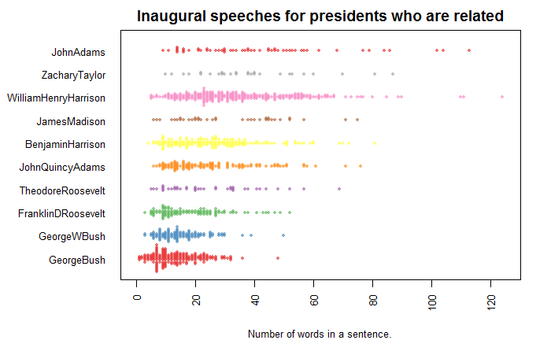

```r
#firstly we select the president from the same family by time from the nearest to most remote(presidents who are related per line)
president_family =c("GeorgeBush","GeorgeWBush",
#                 "HillaryClinton", "WilliamJClinton",
                 "FranklinDRoosevelt","TheodoreRoosevelt",
                 "BenjaminHarrison","WilliamHenryHarrison",
                 "JamesMadison","ZacharyTaylor",
                 "JohnQuincyAdams","JohnAdams")
par(mar=c(4, 8, 2, 2))
sentence.list.family=filter(sentence.list,
                        type=="inaug", Term==1, File%in%president_family)
sentence.list.family$File=factor(sentence.list.family$File)
sentence.list.family$FileOrdered=reorder(sentence.list.family$File,
                                  sentence.list.family$word.count,
                                  mean,
                                  order=T)
beeswarm(word.count~FileOrdered,
         data=sentence.list.family,
         horizontal = TRUE,
         pch=16, col=alpha(brewer.pal(9, "Set1"), 0.6),
         cex=0.55, cex.axis=0.8, cex.lab=0.8,
         spacing=5/nlevels(sentence.list.family$FileOrdered),
         las=2, xlab="Number of words in a sentence.", ylab="",
         main="Inaugural speeches for presidents who are related")
```

```r
NA
```

# Further readings

- [Text mining and word cloud fundamentals in R : 5 simple steps you should know](http://www.sthda.com/english/wiki/text-mining-and-word-cloud-fundamentals-in-r-5-simple-steps-you-should-know).
- [Text mining with `tidytext`](http://tidytextmining.com/).
- [Basic Text Mining in R](https://rstudio-pubs-static.s3.amazonaws.com/31867_8236987cf0a8444e962ccd2aec46d9c3.html)
- [Selectorgadget](http://selectorgadget.com/).
- [Jerid Francom](http://francojc.github.io/web-scraping-with-rvest/).
- [NRC sentiment lexion](http://saifmohammad.com/WebPages/NRC-Emotion-Lexicon.htm).
- [par(mar, mgp, las)](http://rfunction.com/archives/1302).
- [U.S. Presidents Who Were Related to Each Other](http://www.factmonster.com/ipka/A0878156.html).
- [John Quincy Adams](https://en.wikipedia.org/wiki/John_Quincy_Adams).